# Vegetation Data Access

Accessing NDVI data

# STEP 2: AppEEARS API

# STEP 0: Set up

To get started on this notebook, you’ll need to restore any variables from previous notebooks to your workspace. To save time and memory, make sure to specify which variables you want to load.

```python
%store -r
```

You will also need to import any libraries you are using in this notebook, since they won’t carry over from the previous notebook:

```python
# Import libraries
import json
import os
import pathlib
import shutil
from glob import glob

import earthpy.api.appeears as eaapp
import earthpy
import geopandas as gpd
import hvplot.pandas
import hvplot.xarray
import pandas as pd
import rioxarray as rxr
import xarray as xr
```

```python
import json
from glob import glob
import earthpy
import hvplot.xarray
import rioxarray as rxr
import xarray as xr
```

```python
from osmnx import features as osm # Search for locations by name
import geopandas as gpd
import hvplot.pandas
```

```python
data_dir = os.path.join(pathlib.Path.home(), 'bandipur')
# Make the data directory
os.makedirs(data_dir, exist_ok=True)
```

```python
#To visualize the directory path
data_dir
```

```
'/home/jovyan/bandipur'
```

```python
# Search for your site
Chamarajanagar_gdf = osm.features_from_address(
    'Bandipur National park, Karnataka',
    {'name':'Chamarajanagar'},

    dist=1000)
Chamarajanagar_gdf
```

| element | id | geometry | name | name:kn | name:ml | name:ta | wikidata | wikipedia | type | admin_level | boundary | official_name |
| --- | --- | --- | --- | --- | --- | --- | --- | --- | --- | --- | --- | --- |
| relation | 2019940 | POLYGON ((76.40394 11.70685, 76.40352 11.7072,... | Chamarajanagar | ಚಾಮರಾಜನಗರ ಜಿಲ್ಲೆ | ചാമരാജനഗർ ജില്ല | சாமராசநகர் மாவட்டம் | Q862912 | en:Chamarajanagar district | boundary | 5 | administrative | Chamarajanagar District |

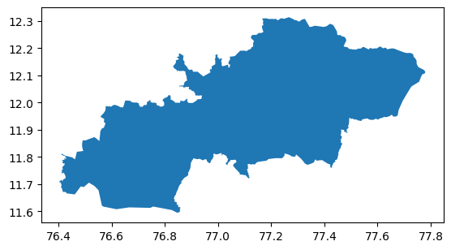

```python
Chamarajanagar_gdf.plot()
```

```python
Chamarajanagar_gdf.explore()
```

Make this Notebook Trusted to load map: File -> Trust Notebook

[interactive chart not shown]

```python
# Plot the results with web tile images
Chamarajanagar_gdf.hvplot(geo=True,tiles='EsriImagery')
```

[output not shown]

## Exploring the AppEEARS API for NASA Earthdata access

Before you get started with the data download today, you will need a free [NASA Earthdata account](https://urs.earthdata.nasa.gov/home) if you don’t have one already!

Over the next four cells, you will download MODIS NDVI data for the study period. MODIS is a multispectral instrument that measures Red and NIR data (and so can be used for NDVI). There are two MODIS sensors on two different platforms: satellites Terra and Aqua.

**Read More**

[Learn more about MODIS datasets and the science they support](https://modis.gsfc.nasa.gov/)

Since we’re asking for a special download that only covers our study area, we can’t just find a link to the data - we have to negotiate with the data server. We’re doing this using the [APPEEARS](https://appeears.earthdatacloud.nasa.gov/api/) API (Application Programming Interface). The API makes it possible for you to request data using code. You can use code from the `earthpy` library to handle the API request.

**Try It**

Often when we want to do something more complex in coding we find an example and modify it. This download code is already almost a working example. Your task will be:

**Reflect and Respond**

What would the product and layer name be if you were trying to download Landsat Surface Temperature Analysis Ready Data (ARD) instead of MODIS NDVI?

> **Important**

> It can take some time for Appeears to process your request - anything from a few minutes to a few hours depending on how busy they are. You can check your progress by:
> 1. Going to the [Appeears webpage](https://appeears.earthdatacloud.nasa.gov/)
> 2. Clicking the `Explore` tab
> 3. Logging in with your Earthdata account

```python
# Initialize AppeearsDownloader for MODIS NDVI data
ndvi_downloader = eaapp.AppeearsDownloader(
    download_key='Chamarajanagar-ndvi',
    # ea_dir=project.project_dir,
    product='MOD13Q1.061',
    layer='_250m_16_days_NDVI',
    start_date="06-01",
    end_date="10-01",
    recurring=True,
    year_range=[2017,2021],
    polygon=Chamarajanagar_gdf
)
# Download the prepared download -- this can take some time!
ndvi_downloader.download_files(cache=True)
```

```
**Final Configuration Loaded:**
{}
Found 'data_home' in environment variables.
No stored credentials found for urs.earthdata.nasa.gov. Please log in.
```

```
Credentials stored using 'env' backend.
```

## Putting it together: Working with multi-file raster datasets in Python

Now you need to load all the downloaded files into Python. You may have noticed that the `earthpy.appears module gives us all the downloaded file names…but only some of those are the NDVI files we want while others are quality files that tell us about the confidence in the dataset. For now, the files we want all have “NDVI” in the name.

Let’s start by getting all the NDVI file names. You will also need to extract the date from the filename. Check out [the lesson on getting information from filenames in the textbook](https://www.earthdatascience.org/courses/intro-to-earth-data-science/write-efficient-python-code/loops/data-workflows-with-loops/). We’re using a slightly different method here (the `.rglob()` or **recursive** glob method, which searchs all the directories nested inside the path), but the principle is the same.

> **GOTCHA ALERT!**

> `glob` doesn’t necessarily find files in the order you would expect. Make sure to **sort** your file names like it says in the textbook.

```python
# Get a sorted list of NDVI tif file paths
#ndvi_paths = sorted(list(project.project_dir.rglob('ndvi-pattern')))
ndvi_paths = sorted(list(ndvi_downloader.download_dir.rglob('*NDVI*.tif')))

# Display the first and last three files paths to check the pattern
ndvi_paths[:3], ndvi_paths[-3:]
```

[output not shown]